# Calculating impedances for CMA and CA areas from the GSS surveys

Bruno Santos, Mahdis Moghadasi & Antonio Paez

2024-11-16

# Introduction

This Rmarkdown file is part of the [**ActiveCA**](https://github.com/dias-bruno/ActiveCA) package.The main objective of the *ActiveCA* package is to identify the most appropriate impedance functions for active transportation modes for various destinations and time periods in Canada. To do achieve our objective, we analyzed historical data from the [General Social Survey (GSS)](https://www23.statcan.gc.ca/imdb/p2SV.pl?Function=getSurvey&SDDS=5221) from 1986 to 2015 in Canada to calculate the impedance function for cycling and walking trips.

In this R markdown, we’ll calculate the impedance functions for walking and cycling for each GSS year (from 1986 to 2015).

## Suggested reading

- Soukhov, A., Páez, A. (2024). Accessibility analysis for planning applications (Report No. MJ-A2-0002). Mobilizing Justice. https://github.com/soukhova/MJ-Accessibility-Blogs

# Coding

To start processing the data, first load the `R` packages used in this notebook:

```r
library(dplyr)# A Grammar of Data Manipulation
library(fitdistrplus) # Help to Fit of a Parametric Distribution to Non-Censored or Censored Data
library(scales) # Scale data column-wise in a computationally efficient way
library(here) # enable easy file referencing in project-oriented workflows
library(ggplot2) # Create Elegant Data Visualisations Using the Grammar of Graphics
```

Soukhov and Páez (2024) explained the process of selecting the best impedance function in detail in a report released by the [*Mobilizing Justice* partnership](https://mobilizingjustice.ca/) using data from the city of Hamilton, Ontario. Subsequently, Santos and Páez (2024) adapted the methodology to create [**CommuteCA**](https://github.com/dias-bruno/CommuteCA), a package to obtain accessibility measures for any Canadian city using the 2021 Population Census as the main data source. Here, we will apply the methodology developed by Santos and Páez (2024) to obtain the impedance functions of the GSS surveys.

Soukhov, Anastasia, and Antonio Páez. 2024. “Accessibility Analysis for Planning Applications.” MJ-A2-0002. Mobilizing Justice. https://github.com/soukhova/MJ-Accessibility-Blogs.

The Mobilizing Justice project is a multidisciplinary and multi-sector collaboration with the objective of understand and address transportation poverty in Canada and to improve the well-being of Canadians at risk of transport poverty. The Social Sciences and Humanities Research Council (SSRHC) has provided funding for the project, which was created by an unprecedented alliance of academics from various Canadian provinces and institutions, transportation firms, and nonprofit organizations

To exemplify the process of selecting the best impedance function, we will use the example of the 1986 GSS dataset, already pre-processed in the `00-Reading-Source-Files.Rmd`:

```r
load(file = paste0(here(), "/data/walking_1986.rda"))
```

First, we’ll analyze the travel time variable (`DURATION`) of the 1986 dataset, using the `summary()` function.

```r
summary(walking_1986$DURATION)
```

```
##    Min. 1st Qu.  Median    Mean 3rd Qu.    Max.
##    1.00    5.00   10.00   20.85   20.00  660.00
```

The minimum duration value for walking trips is `1` minute, while the maximum is `660` minutes. Additionally, the average and median duration for walking trips are `20.85` minutes and `10` minutes, respectively.

Now, we’ll see this variable displayed in a histogram:

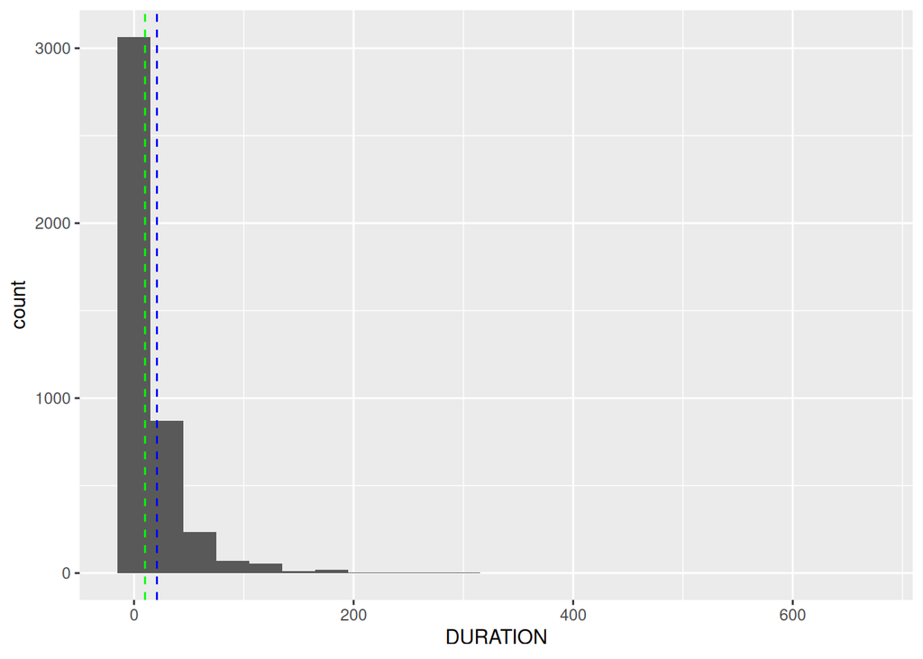

```r
ggplot(walking_1986, aes(x = DURATION )) +
  geom_histogram(binwidth = 30) +
  geom_vline(aes(xintercept=mean(DURATION)), color="blue", linetype="dashed", linewidth=0.5) +
  geom_vline(aes(xintercept=median(DURATION)), color="green", linetype="dashed", linewidth=0.5)
```

A histogram is a graph that illustrates the frequency distribution of a dataset corresponding to a single variable. Histograms displays the distribution and variability of the dataset, typically organizing data into ‘bins’ or ‘range groups,’ tallying the quantity of data points within each bin.

Analyzing the histogram above, we can identify that the just a few values of duration are higher than 1 hundred minutes. To better visualize the variable distribution, let’s use an other type of graph, the box plot graph:

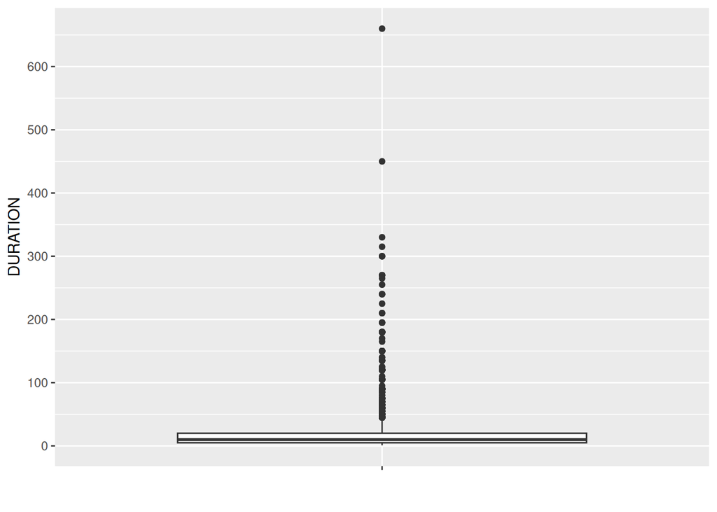

```r
ggplot(walking_1986, aes(y = DURATION, x = "")) +
  geom_boxplot() +
  scale_y_continuous(breaks = seq(0, max(walking_1986$DURATION, na.rm = TRUE), by = 100)) +
  xlab("")
```

We can see that just a few outliers present values higher than 100 minutes. In fact, the chunk below shows that from the 4347 instances of the dataset, 117 have values of duration higher than 100 minutes. Because of this, we’ll analyze only individuals who engaged in walking for less than 100 minutes, focusing on their origins and destinations.

```r
length(walking_1986$DURATION)
```

```
## [1] 4347
```

```r
sum(walking_1986$DURATION > 100)
```

```
## [1] 117
```

Visualizing the new summary:

```r
walking_1986 <- walking_1986 %>% filter(DURATION <= 100)
summary(walking_1986$DURATION)
```

```
##    Min. 1st Qu.  Median    Mean 3rd Qu.    Max.
##    1.00    5.00   10.00   17.03   20.00   95.00
```

After excluding trip longer than 100 minutes duration, the minimum duration value for walking trips is `1` minute (same as before), while the maximum is `95` minutes. The new average duration for walking trips is `17.03` minutes and the median is `10` minutes.

## Impedance functions

The impedance function $f(c_{ij})$ reveals important information about the travel behavior of the population, as it represents the relationship between the “population” at an origin and where they usually go, want to go, or can go to reach the “opportunities” at the destinations. Because of this, defining the impedance function is extremely important.

Soukhov and Páez (2024) reviewed commonly used impedance functions $f(\bullet)$ in accessibility research, explaining their impacts on the summation of opportunities at specific travel costs $c_{ij}$. In this study, we will explore the following functions to determine the impedance function that best fits our data: [exponential](https://en.wikipedia.org/wiki/Exponential_distribution), [gamma](https://en.wikipedia.org/wiki/Gamma_distribution), [log-normal](https://en.wikipedia.org/wiki/Log-normal_distribution), [normal](https://en.wikipedia.org/wiki/Normal_distribution), and [uniform](https://en.wikipedia.org/wiki/Continuous_uniform_distribution).

Soukhov, Anastasia, and Antonio Páez. 2024. “Accessibility Analysis for Planning Applications.” MJ-A2-0002. Mobilizing Justice. https://github.com/soukhova/MJ-Accessibility-Blogs.

# Trip length distribution: exemplifying the case of the 1986 GSS

All of the impedance functions mentioned require the analyst to define parameters. One useful technique is to create a trip length distribution (TLD) using empirically observed origin-destination travel survey data. A TLD reflects observed travel patterns: specifically, the probability of an observed trip of a given travel cost occurring for the population in a region of interest. Based on the TLD, we can select the most appropriate theoretical PDF forms (e.g., uniform, exponential, gamma), adjust the associated parameters, and use the calibrated theoretical PDF to incorporate the assumptions about the population’s travel behavior into the accessibility calculation.

Soukhov and Páez (2024) demonstrated the process of calibrating and selecting the best distribution to represent an impedance function based on travel flows from workers who live and work (full-time) within the City of Hamilton. The authors used the data from the R data package [{TTS2016R}](https://soukhova.github.io/TTS2016R/) and the R package [{fitdistrplus}](https://cloud.r-project.org/web/packages/fitdistrplus/index.html) to generate parameters that best fit the TLD the parameters of the uniform, exponential, and gamma functions as closely to the TLD.

Soukhov, Anastasia, and Antonio Páez. 2024. “Accessibility Analysis for Planning Applications.” MJ-A2-0002. Mobilizing Justice. https://github.com/soukhova/MJ-Accessibility-Blogs.

## Empirical travel time

The next chunks of code of this Rmarkdown explains the process of calibrating PDF functions for the Walking dataset of the 1986 GSS. Creating a data frame with the all empirical travel times:

```r
# Bind the empirical trip length distribution:
tld_empirical <- walking_1986[, c("DURATION", "MODE", "destination", "WGHT_EPI","dest_label")] %>%
  mutate(MODE = factor(MODE, levels = c("Walking","Cycling")),
      distribution = "empirical")

tld_empirical$DURATION <- as.numeric(tld_empirical$DURATION)
```

## Theoretical travel time

Now that we already have the travel times for each trip, we will try to create a impedance function that better describes the travel pattern of the respondents in each destination. To do so, we’ll first create a function that based on the lowest Akaike Information Criterion (AIC), selects the better function between the distributions: [exponential](https://en.wikipedia.org/wiki/Exponential_distribution), [gamma](https://en.wikipedia.org/wiki/Gamma_distribution), [log-normal](https://en.wikipedia.org/wiki/Log-normal_distribution), [normal](https://en.wikipedia.org/wiki/Normal_distribution), and [uniform](https://en.wikipedia.org/wiki/Continuous_uniform_distribution).

The Akaike Information Criterion (AIC) estimates prediction error and model quality for a given data set.

We’ll use the [{fitdistrplus}](https://cloud.r-project.org/web/packages/fitdistrplus/index.html) to determine the parameters that best fit the TLD. The Moment Matching Estimation (MME) fitting method and the Nelder-Mead direct optimization algorithm are used (Delignette-Muller and Dutang 2015).

Delignette-Muller, Marie Laure, and Christophe Dutang. 2015. “Fitdistrplus: An r Package for Fitting Distributions.” *Journal of Statistical Software* 64 (4): 1–34. https://doi.org/10.18637/jss.v064.i04.

The code below introduces two functions: `test_distributions_weighted` and `lowest_aic`. The first takes the time values as input and applies them to the distributions mentioned above, obtaining an AIC value for each distribution. In turn, `lowest_aic` compares the AIC values of each distribution and selects the function with the minimum AIC (the distribution with the best fit considering the time values provided).

```r
# Select the distribution function based on the lowest AIC value
lowest_aic <- function(values){

  min_aic <- min(values)

  if(!is.na(lnorm_$aic) & min_aic == lnorm_$aic){
    choosen_f <- lnorm_
  }

  else if  (!is.na(gamma_$aic) & min_aic == gamma_$aic){
    choosen_f <- gamma_
  }

  else if  (!is.na(unif_$aic) & min_aic == unif_$aic){
    choosen_f <- unif_
  }

  else if  (!is.na(norm_$aic) & min_aic == norm_$aic){
    choosen_f <- norm_
  }
  else if  (!is.na(exp_$aic) & min_aic == exp_$aic){
    choosen_f <- exp_
  }

  return(choosen_f)
}

# Test the distributions
test_distributions_weighted <- function(x, weights){
  gamma_ <<- fitdistrplus::fitdist(data=x, "gamma", method="mme", weights = weights)
  lnorm_ <<- fitdistrplus::fitdist(data=x, "lnorm", method="mme", weights = weights)
  norm_ <<- fitdistrplus::fitdist(data=x, "norm", method="mme", weights = weights)
  exp_ <<- fitdistrplus::fitdist(data=x, "exp", method="mme", weights = weights)
  unif_ <<- fitdistrplus::fitdist(data=x, "unif", method="mme", weights = weights)

  values <- c(lnorm_$aic, gamma_$aic, unif_$aic, norm_$aic, exp_$aic)
  values <- values[!is.na(values)]

  chosen_function <- lowest_aic(values)

  return(chosen_function)
}
```

The next chunk selects the best impedance function, using the `test_distributions_weighted` and `lowest_aic` functions for each destination and transportation mode (in this case, walking since the 1986 survey does not have cycling as an mode option). The name pattern is as follows: `f_year_mode_dest` + `destination`, which means that `f_1986_Walking_dest1` displays the best function for the year 1986, walking mode, destination 1 (Home).

```r
for(destino in unique(tld_empirical$destination)){
  assign(paste0("f_1986_Walking_dest", destino),
         test_distributions_weighted(
           x = tld_empirical[tld_empirical$destination == destino, ]$DURATION,
           weights = round(tld_empirical[tld_empirical$destination == destino, ]$WGHT_EPI)))
}
```

Based on the minimum AIC, the best function for the destination `1` (`Home`), considering walking as the mode of transportation, is the `Log-normal distribution`:

```r
f_1986_Walking_dest1
```

```
## Fitting of the distribution ' lnorm ' by matching moments
## Parameters:
##          estimate Std. Error
## meanlog 2.8148444   1.085182
## sdlog   0.7775823   1.309553
```

Actually, the `Log-normal distribution` was the best function for the others two destination from the survey: `2` (`Work or school`) and `3` (`Other's home`).

```r
f_1986_Walking_dest2
```

```
## Fitting of the distribution ' lnorm ' by matching moments
## Parameters:
##          estimate Std. Error
## meanlog 2.2550485   1.158082
## sdlog   0.7963278   1.398182
```

```r
f_1986_Walking_dest3
```

```
## Fitting of the distribution ' lnorm ' by matching moments
## Parameters:
##          estimate Std. Error
## meanlog 2.3070069   1.131924
## sdlog   0.7898262   1.366714
```

The chunk below aims to create functions to graphically display the theoretical values obtained in the chunks:

```r
# For Displaying theoretical data

visualize_impedance <- function(destination_function, travel_cost, name_destination){

  x <- data.frame(t = seq(1, max(travel_cost), 1))

  # lnorm impedance
  if(destination_function$distname == "lnorm"){
      x <- x %>%
      mutate(f = dlnorm(t,
                    meanlog = destination_function$estimate[1],
                    sdlog = destination_function$estimate[2]),
         destination = name_destination)

  # Unif impedance
  } else if(destination_function$distname == "unif") {
    x <- x %>%
    mutate(f = dunif(t,
                     min=0,
                     max=destination_function$estimate[2]), #already scaled from 1 to 0
         destination = name_destination)

  # Exponential impedance
  } else if(destination_function$distname == "exp") {
    x <- x %>%
    mutate(f = dexp(t,
                    rate = destination_function$estimate), #|> scales::rescale(),
         destination = name_destination)

  # Gamma impedance
  } else if (destination_function$distname == "gamma"){
    x <- x %>%
        mutate(f = dgamma(t,
                    shape = destination_function$estimate[1],
                    rate = destination_function$estimate[2]),
         destination = name_destination)

  # Norm impedance
  } else if (destination_function$distname == "norm"){
        x <- x %>%
        mutate(f = dnorm(t,
                    mean = destination_function$estimate[1],
                    sd = destination_function$estimate[2]),
         destination = name_destination)
        }

  return(x)
}
```

Obtaining the theoretical values for each destination based on the best impedance function for each destination:

```r
# Theoretical values for bike destination
tld_theoretical <- data.frame()

for(destino in unique(tld_empirical$destination)){

  current_function <- paste0("f_1986_Walking_dest", destino)

  assign(paste0("theo_1986_Walking_dest", destino),
         visualize_impedance(destination_function = get(current_function),
                             travel_cost = tld_empirical[tld_empirical$destination == destino, ]$DURATION,
                             name_destination = destino))

  tld_theoretical <- rbind(tld_theoretical, get(paste0("theo_1986_Walking_dest", destino)))
  }
```

Visualizing the theoretical values (first 10 rows):

```r
tld_theoretical[1:10,]
```

```
##     t           f destination
## 1   1 0.009088313           2
## 2   2 0.036594886           2
## 3   3 0.058176998           2
## 4   4 0.069074135           2
## 5   5 0.072130558           2
## 6   6 0.070496747           2
## 7   7 0.066373601           2
## 8   8 0.061117900           2
## 9   9 0.055517604           2
## 10 10 0.050008563           2
```

Plotting the theoretical (black lines) and the empirical travel time distributions (bars):

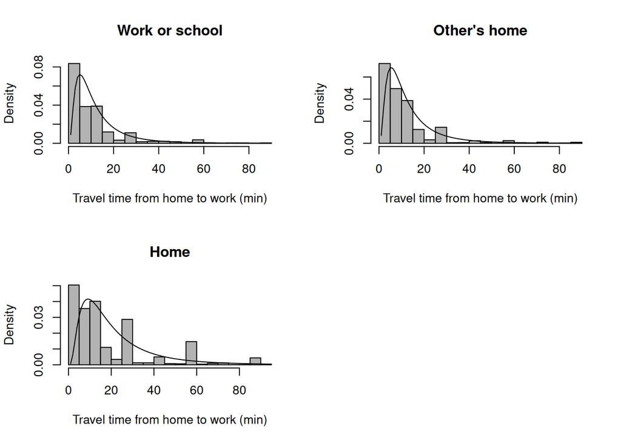

```r
par(mfrow = c(2, round(length(unique(tld_theoretical$destination))/2)))

# Loop through each destination
for (destination in unique(tld_empirical$destination)) {
  empirical_subset <- tld_empirical[tld_empirical$destination == destination, ]
  theoretical_subset <- tld_theoretical[tld_theoretical$destination == destination, ]

hist(empirical_subset$DURATION, freq = FALSE, col = "grey70", breaks = 20, main = paste(empirical_subset$dest_label[1]),
       xlab = "Travel time from home to work (min)", ylab = "Density")

  lines(theoretical_subset$t, theoretical_subset$f)
}

# Reset plotting parameters
par(mfrow = c(1, 1))
```

# Calculating for all GSS cicles

After exemplifying the process of selecting the best impedance function for the 1986 GSS survey, we will obtain the function for all GSS cycles. First, we’ll load the GSS episodes pre-processed in the first rmarkdown:

```r
load(file = paste0(here(), "/data/gss_episodes.rda"))
```

Additionally, our analysis will focus on developing impedance functions considering only the population who lives in larger urban population centre (a Census Metropolitan Area (CMA) or Census Agglomeration (CA)). We decided to apply this restriction because the travel behavior among residents of the CMA and CA areas, in terms of active travel, tends to be very different from those outside these large urban population centers. The variable that informs if the respondent resides in a CMA or CA region is the variable named `Pop_centre`, obtained after some processing made with he Main File survey.

For definitions of CMA and CA check the this [website](https://www12.statcan.gc.ca/census-recensement/2021/ref/dict/az/Definition-eng.cfm?ID=geo009).

```r
gss_episodes <- gss_episodes %>%
  filter(DURATION <= 100 &
           DURATION > 0 &
           YEAR > 1986 &
           Pop_centre %in% c("CMA/CA", "CMA"))
```

Furthermore, to calculate the function, we need a combination of `mode`, `year` and `destination` greater than 1, which means that we need at least two episodes to be able to fit a function. Consequently, combinations with a greater number of episodes will exhibit better functions in terms of AIC and will better represent the empirical values.

```r
gss_episodes <- gss_episodes %>%
  group_by(MODE, YEAR, dest_label) %>%
  mutate(count = n()) %>%
  ungroup() %>%
  filter(count > 1)

gss_episodes$WGHT_EPI[is.na(gss_episodes$WGHT_EPI)] <- 1
```

```r
for(year in unique(gss_episodes$YEAR)){

  for(destino in unique(gss_episodes[gss_episodes$YEAR == year, ]$dest_label)){

    for(mode in unique(gss_episodes[gss_episodes$YEAR == year & gss_episodes$dest_label == destino, ]$MODE)){

        gss_subset <-  gss_episodes[gss_episodes$dest_label == destino &
                            gss_episodes$YEAR == year &
                            gss_episodes$MODE == mode, ]

        if(nrow(gss_subset) > 0){
          print(paste("Calculating the best function for ",
                    mode, ", destination ",
                    destino,
                    ", for the ", year, " GSS cicle"))

          assign(paste0("f_",year, "_", mode, "_dest", destino),
               test_distributions_weighted(
               x = gss_subset$DURATION,
               weights = round(gss_subset$WGHT_EPI)))
        }
    }
  }
}
```

```
## [1] "Calculating the best function for  Walking , destination  Restaurant, bar or club , for the  2015  GSS cicle"
```

```
## [1] "Calculating the best function for  Cycling , destination  Restaurant, bar or club , for the  2015  GSS cicle"
```

```
## [1] "Calculating the best function for  Walking , destination  Sports centre, field or arena , for the  2015  GSS cicle"
```

```
## [1] "Calculating the best function for  Cycling , destination  Sports centre, field or arena , for the  2015  GSS cicle"
```

```
## [1] "Calculating the best function for  Walking , destination  Grocery store, other stores or mall , for the  2015  GSS cicle"
```

```
## [1] "Calculating the best function for  Cycling , destination  Grocery store, other stores or mall , for the  2015  GSS cicle"
```

```
## [1] "Calculating the best function for  Walking , destination  Home , for the  2015  GSS cicle"
```

```
## [1] "Calculating the best function for  Cycling , destination  Home , for the  2015  GSS cicle"
```

```
## [1] "Calculating the best function for  Walking , destination  Work or school , for the  2015  GSS cicle"
```

```
## [1] "Calculating the best function for  Cycling , destination  Work or school , for the  2015  GSS cicle"
```

```
## [1] "Calculating the best function for  Walking , destination  Library, museum or theatre , for the  2015  GSS cicle"
```

```
## [1] "Calculating the best function for  Cycling , destination  Library, museum or theatre , for the  2015  GSS cicle"
```

```
## [1] "Calculating the best function for  Walking , destination  Other's home , for the  2015  GSS cicle"
```

```
## [1] "Calculating the best function for  Cycling , destination  Other's home , for the  2015  GSS cicle"
```

```
## [1] "Calculating the best function for  Walking , destination  Place of worship , for the  2015  GSS cicle"
```

```
## [1] "Calculating the best function for  Walking , destination  In the neighbourhood , for the  2015  GSS cicle"
```

```
## [1] "Calculating the best function for  Cycling , destination  In the neighbourhood , for the  2015  GSS cicle"
```

```
## [1] "Calculating the best function for  Walking , destination  Outdoors , for the  2015  GSS cicle"
```

```
## [1] "Calculating the best function for  Cycling , destination  Outdoors , for the  2015  GSS cicle"
```

```
## [1] "Calculating the best function for  Walking , destination  Medical, dental or other health clinic , for the  2015  GSS cicle"
```

```
## [1] "Calculating the best function for  Cycling , destination  Medical, dental or other health clinic , for the  2015  GSS cicle"
```

```
## [1] "Calculating the best function for  Walking , destination  Business , for the  2015  GSS cicle"
```

```
## [1] "Calculating the best function for  Walking , destination  Grocery store, other stores or mall , for the  2010  GSS cicle"
```

```
## [1] "Calculating the best function for  Cycling , destination  Grocery store, other stores or mall , for the  2010  GSS cicle"
```

```
## [1] "Calculating the best function for  Walking , destination  Home , for the  2010  GSS cicle"
```

```
## [1] "Calculating the best function for  Cycling , destination  Home , for the  2010  GSS cicle"
```

```
## [1] "Calculating the best function for  Walking , destination  Work or school , for the  2010  GSS cicle"
```

```
## [1] "Calculating the best function for  Cycling , destination  Work or school , for the  2010  GSS cicle"
```

```
## [1] "Calculating the best function for  Walking , destination  Other's home , for the  2010  GSS cicle"
```

```
## [1] "Calculating the best function for  Cycling , destination  Other's home , for the  2010  GSS cicle"
```

```
## [1] "Calculating the best function for  Walking , destination  Restaurant, bar or club , for the  2010  GSS cicle"
```

```
## [1] "Calculating the best function for  Cycling , destination  Restaurant, bar or club , for the  2010  GSS cicle"
```

```
## [1] "Calculating the best function for  Walking , destination  Outdoors , for the  2010  GSS cicle"
```

```
## [1] "Calculating the best function for  Cycling , destination  Outdoors , for the  2010  GSS cicle"
```

```
## [1] "Calculating the best function for  Walking , destination  Place of worship , for the  2010  GSS cicle"
```

```
## [1] "Calculating the best function for  Walking , destination  Library, museum or theatre , for the  2010  GSS cicle"
```

```
## [1] "Calculating the best function for  Cycling , destination  Library, museum or theatre , for the  2010  GSS cicle"
```

```
## [1] "Calculating the best function for  Walking , destination  Outdoors , for the  2005  GSS cicle"
```

```
## [1] "Calculating the best function for  Cycling , destination  Outdoors , for the  2005  GSS cicle"
```

```
## [1] "Calculating the best function for  Walking , destination  Home , for the  2005  GSS cicle"
```

```
## [1] "Calculating the best function for  Cycling , destination  Home , for the  2005  GSS cicle"
```

```
## [1] "Calculating the best function for  Walking , destination  Work or school , for the  2005  GSS cicle"
```

```
## [1] "Calculating the best function for  Cycling , destination  Work or school , for the  2005  GSS cicle"
```

```
## [1] "Calculating the best function for  Walking , destination  Restaurant, bar or club , for the  2005  GSS cicle"
```

```
## [1] "Calculating the best function for  Cycling , destination  Restaurant, bar or club , for the  2005  GSS cicle"
```

```
## [1] "Calculating the best function for  Walking , destination  Other's home , for the  2005  GSS cicle"
```

```
## [1] "Calculating the best function for  Cycling , destination  Other's home , for the  2005  GSS cicle"
```

```
## [1] "Calculating the best function for  Walking , destination  Grocery store, other stores or mall , for the  2005  GSS cicle"
```

```
## [1] "Calculating the best function for  Cycling , destination  Grocery store, other stores or mall , for the  2005  GSS cicle"
```

```
## [1] "Calculating the best function for  Walking , destination  Library, museum or theatre , for the  2005  GSS cicle"
```

```
## [1] "Calculating the best function for  Cycling , destination  Library, museum or theatre , for the  2005  GSS cicle"
```

```
## [1] "Calculating the best function for  Walking , destination  Place of worship , for the  2005  GSS cicle"
```

```
## [1] "Calculating the best function for  Cycling , destination  Other's home , for the  1998  GSS cicle"
```

```
## [1] "Calculating the best function for  Walking , destination  Other's home , for the  1998  GSS cicle"
```

```
## [1] "Calculating the best function for  Cycling , destination  Home , for the  1998  GSS cicle"
```

```
## [1] "Calculating the best function for  Walking , destination  Home , for the  1998  GSS cicle"
```

```
## [1] "Calculating the best function for  Cycling , destination  Work or school , for the  1998  GSS cicle"
```

```
## [1] "Calculating the best function for  Walking , destination  Work or school , for the  1998  GSS cicle"
```

```
## [1] "Calculating the best function for  Walking , destination  Work or school , for the  1992  GSS cicle"
```

```
## [1] "Calculating the best function for  Cycling , destination  Work or school , for the  1992  GSS cicle"
```

```
## [1] "Calculating the best function for  Walking , destination  Other's home , for the  1992  GSS cicle"
```

```
## [1] "Calculating the best function for  Cycling , destination  Other's home , for the  1992  GSS cicle"
```

```
## [1] "Calculating the best function for  Walking , destination  Home , for the  1992  GSS cicle"
```

```
## [1] "Calculating the best function for  Cycling , destination  Home , for the  1992  GSS cicle"
```

After selecting the best function for every combination of destination, transportation mode and year, the next two chunks will apply the functions in all surveys, adding the information with the best function and its parameters, AIC/BIC/loglik values, and count of episodes that were used to calculate the function:

```r
# To generate the theoretical data
generate_impedance <- function(destination_function, travel_cost){

  f <- 0

  # lnorm impedance
  if(destination_function$distname == "lnorm"){
  f <- dlnorm(travel_cost,
                    meanlog = destination_function$estimate[1],
                    sdlog = destination_function$estimate[2])

   estimate_1 <- destination_function$estimate[1]
   estimate_2 <- destination_function$estimate[2]
  }

  # Unif impedance
  else if(destination_function$distname == "unif") {
   f <- dunif(travel_cost,
                     min=0,
                     max=destination_function$estimate[2])

   estimate_1 <- 0
   estimate_2 <- destination_function$estimate[2]

  # Exponential impedance
  } else if(destination_function$distname == "exp") {
    f <- rescale(dexp(travel_cost,
                    rate = destination_function$estimate))

   estimate_1 <- destination_function$estimate
   estimate_2 <- 0

      # Gamma impedance
  } else if (destination_function$distname == "gamma"){
    f <- dgamma(travel_cost,
                    shape = destination_function$estimate[1],
                    rate = destination_function$estimate[2])

   estimate_1 <- destination_function$estimate[1]
   estimate_2 <- destination_function$estimate[2]

  # Norm impedance
  } else if (destination_function$distname == "norm"){
        f <- dnorm(travel_cost,
                    mean = destination_function$estimate[1],
                    sd = destination_function$estimate[2])

   estimate_1 <- destination_function$estimate[1]
   estimate_2 <- destination_function$estimate[2]

  }

  df_f <- data.frame("f_name" = rep(destination_function$distname, length(f)),
           "f" = f,
           "est_1" = rep(estimate_1, length(f)),
           "est_2" = rep(estimate_2, length(f)))

  return(df_f)
}
```

```r
gss_episodes$f_name <- ''
gss_episodes$f <- 0
gss_episodes$est_1 <- 0
gss_episodes$est_2 <- 0
gss_episodes$loglik <- 0
gss_episodes$aic <- 0
gss_episodes$bic <- 0

for(year in unique(gss_episodes$YEAR)){

  for(destino in unique(gss_episodes[gss_episodes$YEAR == year, ]$dest_label)){

    for(mode in unique(gss_episodes[gss_episodes$YEAR == year & gss_episodes$dest_label == destino, ]$MODE)){

        gss_subset <-  gss_episodes[gss_episodes$dest_label == destino &
                            gss_episodes$YEAR == year &
                            gss_episodes$MODE == mode ,
                            ]

        if(nrow(gss_subset) > 0){

                    print(paste("Obtaining the values for ",
                    mode, ", destination ",
                    destino,
                    ", for the ", year, " GSS cicle"))

        current_function <- paste0("f_",year, "_", mode, "_dest", destino)

        df_f <- generate_impedance(destination_function = get(current_function),
                                   travel_cost = gss_subset$DURATION)

        gss_episodes[gss_episodes$dest_label == destino &
                            gss_episodes$YEAR == year &
                            gss_episodes$MODE == mode ,
                            c("f_name","f","est_1","est_2")] <- df_f[,c("f_name","f","est_1","est_2")]

        gss_episodes[gss_episodes$dest_label == destino &
                            gss_episodes$YEAR == year &
                            gss_episodes$MODE == mode ,
                            c("loglik", "aic", "bic")] <- list(get(current_function)$loglik, get(current_function)$aic, get(current_function)$bic)
        }
      }
  }
}
```

```
## [1] "Obtaining the values for  Walking , destination  Restaurant, bar or club , for the  2015  GSS cicle"
## [1] "Obtaining the values for  Cycling , destination  Restaurant, bar or club , for the  2015  GSS cicle"
## [1] "Obtaining the values for  Walking , destination  Sports centre, field or arena , for the  2015  GSS cicle"
## [1] "Obtaining the values for  Cycling , destination  Sports centre, field or arena , for the  2015  GSS cicle"
## [1] "Obtaining the values for  Walking , destination  Grocery store, other stores or mall , for the  2015  GSS cicle"
## [1] "Obtaining the values for  Cycling , destination  Grocery store, other stores or mall , for the  2015  GSS cicle"
## [1] "Obtaining the values for  Walking , destination  Home , for the  2015  GSS cicle"
## [1] "Obtaining the values for  Cycling , destination  Home , for the  2015  GSS cicle"
## [1] "Obtaining the values for  Walking , destination  Work or school , for the  2015  GSS cicle"
## [1] "Obtaining the values for  Cycling , destination  Work or school , for the  2015  GSS cicle"
## [1] "Obtaining the values for  Walking , destination  Library, museum or theatre , for the  2015  GSS cicle"
## [1] "Obtaining the values for  Cycling , destination  Library, museum or theatre , for the  2015  GSS cicle"
## [1] "Obtaining the values for  Walking , destination  Other's home , for the  2015  GSS cicle"
## [1] "Obtaining the values for  Cycling , destination  Other's home , for the  2015  GSS cicle"
## [1] "Obtaining the values for  Walking , destination  Place of worship , for the  2015  GSS cicle"
```

[output cut: 49 more lines]

Creation of a new dataset called `gss_impedances`, to keep the original episode files as they are after the pre-processing stage:

```r
gss_impedances <- gss_episodes[,c("PUMFID","DURATION",
                                  "origin","destination","Province","Pop_centre","orig_label",
                                  "dest_label","YEAR","MODE","f_name",
                                  "f","est_1","est_2","loglik","aic","bic","count")]
```

Save this data frame in R format:

```r
usethis::use_data(gss_impedances, overwrite = TRUE)
```